# Sexual dimorphism in *Fringilla coelebs*

Emma Rand

# Introduction

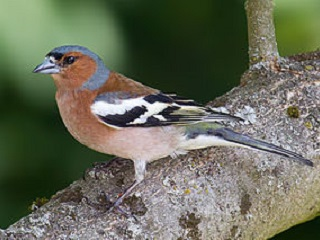

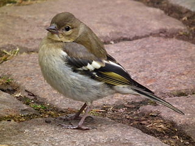

Figure 1: Adult *Fringilla coelebs* Left, male (by Andreas Trepte, CC BY-SA 2.5 https://creativecommons.org/licenses/by-sa/2.5, via Wikimedia Commons); right, female (4028mdk09, CC BY-SA 3.0 https://creativecommons.org/licenses/by-sa/3.0, via Wikimedia Commons)

# Methods

We randomly sampled 20 male and 20 female birds on the stray and determined their mass with spring scales. Analysis was carried out with R version 4.1.1 (R Core Team 2021) and tidyverse packages (Wickham 2017).

# Results

We wouldn’t normally report the sum of the squared deviations ($SS(x)$) but we do so here to make use of a function. For males, the $SS(x)$ = 87.9 and for females, the $SS(x)$ = 86.83

Males ($\bar{x} \pm s.e.$: 22.27 $\pm$ 0.48 g) have significantly higher mass than females (20.48 $\pm$ 0.48 g)($t$ = 2.65; $d.f.$ = 38; $p$ = 0.012). See figure 2.

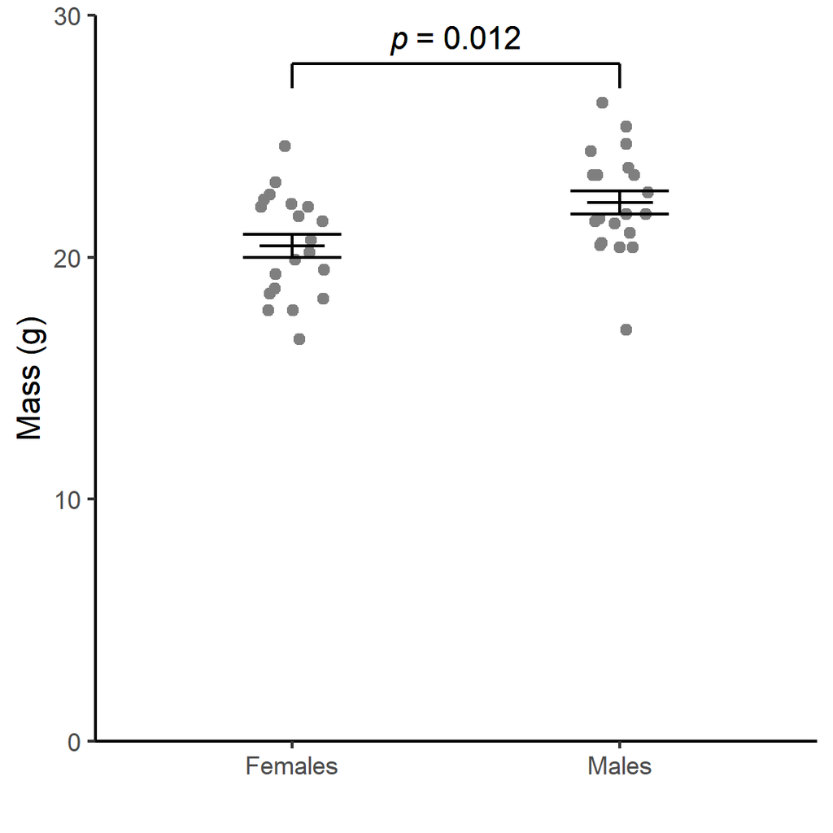

Figure 2: Mass of adult chaffinches caught on the Stray. Error bars are $\bar{x} \pm 1 s.e.$

I’ve also gratuitously included a table with the same information just for the sake of including a table. See Table 1.

Table 1: A summary of the data.

| sex | mean | std | n | se | ssx |
| --- | --- | --- | --- | --- | --- |
| females | 20 | 2.1 | 20 | 0.48 | 87 |
| males | 22 | 2.1 | 20 | 0.48 | 88 |

# Discussion

Here we pick up points from the introduction.

## Word count

Word count calculated with package **`wordcountaddin`** (Marwick 2020)

This doc: 273  
The README: 609  
Total: 882

# References

Cramp, Stanley. 1994. *Handbook of the Birds of Europe the Middle East and North Africa. The Birds of the Western Palearctic, Volume 8: Crows to Finches*. Vol. 8 Crows to Finches. Oxford University Press.

Marwick, Ben. 2020. *Wordcountaddin: Word Counts and Readability Statistics in r Markdown Documents*.

R Core Team. 2021. *R: A Language and Environment for Statistical Computing*. Vienna, Austria: R Foundation for Statistical Computing. https://www.R-project.org/.

Wickham, Hadley. 2017. *Tidyverse: Easily Install and Load the ’Tidyverse’*. https://CRAN.R-project.org/package=tidyverse.